# In Exploratory Data Analysis what all things we do.

# Team won by Minimum Wickets

```python
df.iloc[df[df['win_by_wickets'].ge(1)].win_by_wickets.idxmin()]
```

```
id                                   560
season                              2015
city                             Kolkata
date                          2015-05-09
team1                    Kings XI Punjab
team2              Kolkata Knight Riders
toss_winner              Kings XI Punjab
toss_decision                        bat
result                            normal
dl_applied                             0
winner             Kolkata Knight Riders
win_by_runs                            0
win_by_wickets                         1
player_of_match               AD Russell
venue                       Eden Gardens
umpire1                     AK Chaudhary
umpire2                  HDPK Dharmasena
umpire3                              NaN
Name: 559, dtype: object
```

```python
df.iloc[df[df['win_by_wickets'].ge(1)].win_by_wickets.idxmin()]['winner']
```

```
'Kolkata Knight Riders'
```

# Observation

1. Mumbai Indians is the team which won by maximum and minimum runs
2. Kolkata Knight Riders is the team which won by maximum and minimum wickets

# The season with has highest number of matches.

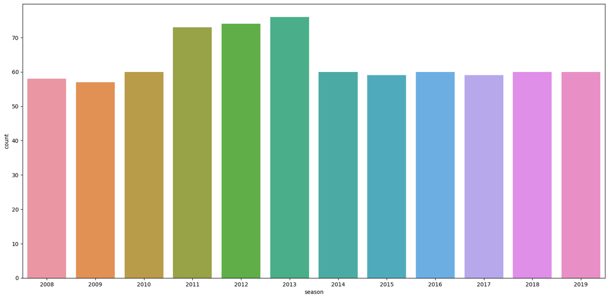

```python
plt.figure(figsize=(19,9))
sns.countplot(x='season',data=df)
plt.show()
```

In 2013, we have the most number of matches

# Which team has winning in most of the matches

```python
data=df['winner'].value_counts()
data.index
```

```
Index(['Mumbai Indians', 'Chennai Super Kings', 'Kolkata Knight Riders',
       'Royal Challengers Bangalore', 'Kings XI Punjab', 'Rajasthan Royals',
       'Delhi Daredevils', 'Sunrisers Hyderabad', 'Deccan Chargers',
       'Gujarat Lions', 'Pune Warriors', 'Rising Pune Supergiant',
       'Delhi Capitals', 'Kochi Tuskers Kerala', 'Rising Pune Supergiants'],
      dtype='object', name='winner')
```

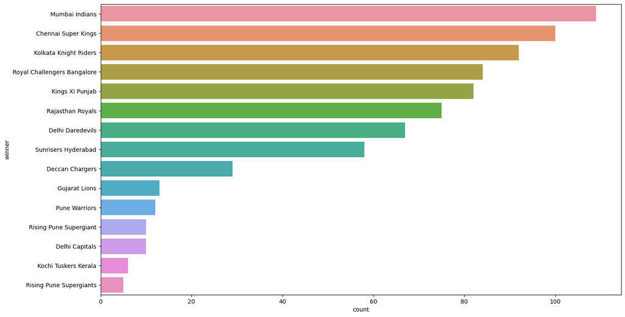

```python
plt.figure(figsize=(16,9))
sns.barplot(y=data.index,x=data,orient='h')
plt.show()
```

Mumbai Indians are the winners in most of the matches

# Performance Trends Over Seasons

```python
team_performance_season = df.groupby(['season', 'winner']).size().unstack().fillna(0)
```

```python
team_performance_season
```

| winner season | Chennai Super Kings | Deccan Chargers | Delhi Capitals | Delhi Daredevils | Gujarat Lions | Kings XI Punjab | Kochi Tuskers Kerala | Kolkata Knight Riders | Mumbai Indians | Pune Warriors | Rajasthan Royals | Rising Pune Supergiant | Rising Pune Supergiants | Royal Challengers Bangalore | Sunrisers Hyderabad |
| --- | --- | --- | --- | --- | --- | --- | --- | --- | --- | --- | --- | --- | --- | --- | --- |
| 2008 | 9.0 | 2.0 | 0.0 | 7.0 | 0.0 | 10.0 | 0.0 | 6.0 | 7.0 | 0.0 | 13.0 | 0.0 | 0.0 | 4.0 | 0.0 |
| 2009 | 8.0 | 9.0 | 0.0 | 10.0 | 0.0 | 7.0 | 0.0 | 3.0 | 5.0 | 0.0 | 6.0 | 0.0 | 0.0 | 9.0 | 0.0 |
| 2010 | 9.0 | 8.0 | 0.0 | 7.0 | 0.0 | 4.0 | 0.0 | 7.0 | 11.0 | 0.0 | 6.0 | 0.0 | 0.0 | 8.0 | 0.0 |
| 2011 | 11.0 | 6.0 | 0.0 | 4.0 | 0.0 | 7.0 | 6.0 | 8.0 | 10.0 | 4.0 | 6.0 | 0.0 | 0.0 | 10.0 | 0.0 |
| 2012 | 10.0 | 4.0 | 0.0 | 11.0 | 0.0 | 8.0 | 0.0 | 12.0 | 10.0 | 4.0 | 7.0 | 0.0 | 0.0 | 8.0 | 0.0 |
| 2013 | 12.0 | 0.0 | 0.0 | 3.0 | 0.0 | 8.0 | 0.0 | 6.0 | 13.0 | 4.0 | 11.0 | 0.0 | 0.0 | 9.0 | 10.0 |
| 2014 | 10.0 | 0.0 | 0.0 | 2.0 | 0.0 | 12.0 | 0.0 | 11.0 | 7.0 | 0.0 | 7.0 | 0.0 | 0.0 | 5.0 | 6.0 |
| 2015 | 10.0 | 0.0 | 0.0 | 5.0 | 0.0 | 3.0 | 0.0 | 7.0 | 10.0 | 0.0 | 7.0 | 0.0 | 0.0 | 8.0 | 7.0 |
| 2016 | 0.0 | 0.0 | 0.0 | 7.0 | 9.0 | 4.0 | 0.0 | 8.0 | 7.0 | 0.0 | 0.0 | 0.0 | 5.0 | 9.0 | 11.0 |
| 2017 | 0.0 | 0.0 | 0.0 | 6.0 | 4.0 | 7.0 | 0.0 | 9.0 | 12.0 | 0.0 | 0.0 | 10.0 | 0.0 | 3.0 | 8.0 |
| 2018 | 11.0 | 0.0 | 0.0 | 5.0 | 0.0 | 6.0 | 0.0 | 9.0 | 6.0 | 0.0 | 7.0 | 0.0 | 0.0 | 6.0 | 10.0 |
| 2019 | 10.0 | 0.0 | 10.0 | 0.0 | 0.0 | 6.0 | 0.0 | 6.0 | 11.0 | 0.0 | 5.0 | 0.0 | 0.0 | 5.0 | 6.0 |

# Observation

The performance trends indicate that Mumbai Indians and Chennai Super Kings are the most successful teams, consistently winning matches across multiple seasons. Other teams, like Deccan Chargers and Gujarat Lions, had brief periods of success, while teams like Pune Warriors and Kochi Tuskers Kerala had minimal impact.

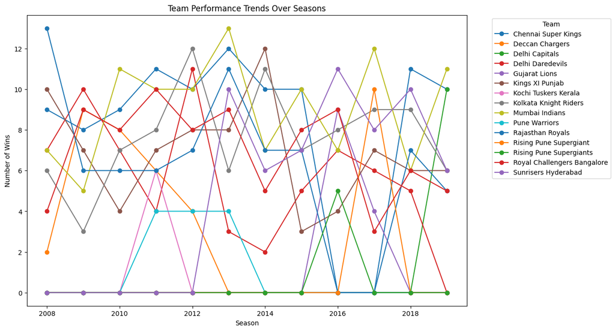

```python
#Performance Trends Over Seasons
plt.figure(figsize=(12, 8))
team_performance_season.plot(kind='line', figsize=(12, 8), marker='o')
plt.title('Team Performance Trends Over Seasons')
plt.xlabel('Season')
plt.ylabel('Number of Wins')
plt.legend(title='Team', bbox_to_anchor=(1.05, 1), loc='upper left')
plt.show()
```

# Correction

Mumbai Indians and Chennai Super Kings consistently performed well, while some teams like Deccan Chargers and Gujarat Lions had brief periods of success.